# Random Forest Analysis on Diabetic Patients Features

Danilo Zavarize

August 12, 2022

#### In this assignment, you will use the Diabetes2.csv data to perform random forest classification with class imbalance correction. If an answer requires a written response, use ‘##’ before your answer. You will submit (1) .R Script file and (1) .RData file, which contains all objects in your workspace created while completing the homework assignment. If you have extra objects in your workspace, clear your workspace, run your HW file and then save your workspace using save.image().

#### Note: Your files should be named using the following format: HW#_Group#. For instance, HW #4 for Group 30 would be: HW4_Group30.R and HW4_Group30.RData.

#### The Diabetes2.csv file contains medical data regarding diabetes in females of Pima Native American heritage. The independent variables include medical and demographic information and the variable of interest, diabetes, indicates if the individual is positive or negative for diabetes. A doctor would like to use this data set to build predictive models. She prioritizes correctly predicting positive (pos) diabetes diagnoses and wants to avoid false negative diagnoses.

#### **VARIABLES DESCRIPTION**

- **`pregnant`**: *number of prior pregnancies*;
- **`glucose`**: *glucose concentration after 2 hours into glucose tolerance test*;
- **`pressure`**: *diastolic blood pressure*;
- **`triceps`**: *triceps skin thickness*;
- **`insulin`**: *2 hour serum insulin*;
- **`mass`**: *body mass index (BMI)*;
- **`pedigree`**: *diabetes pedigree function*;
- **`age`**: *individual’s age (in years)*;
- **`diabetes`**: *if the individual has diabetes (pos) or not (neg)*;

#### **PRELIMINARY STEPS**

- **Loading Libraries**

  ```r
  library(DescTools)
  library(caret)
  library(randomForest)
  library(readr)
  library(ggplot2)
  library(ROSE)
  library(rpart)
  library(ConfusionTableR)
  ```

- **0a. To begin, import the Diabetes2.csv data set as a data frame named `Diab`. Since the only character variable is the target (Y) variable, diabetes, set stringsAsFactors = TRUE to import it as a factor variable.**

  ```r
  Diab <- read.csv("Diabetes2.csv", stringsAsFactors = TRUE)
  head(Diab, 5)
  ```

  ```
  ##   pregnant glucose pressure triceps insulin mass pedigree age diabetes
  ## 1        6     148       72      35      NA 33.6    0.627  50      pos
  ## 2        1      85       66      29      NA 26.6    0.351  31      neg
  ## 3        8     183       64       0       0 23.3    0.672  32      pos
  ## 4        1      89       66      23      94 28.1    0.167  21      neg
  ## 5        0     137       40      35     168 43.1    2.288  33      pos
  ```

- **0b. Obtain structure and summary information for the Diab dataframe.**

  ```r
  # Structure
  str(Diab)
  ```

  ```
  ## 'data.frame':    768 obs. of  9 variables:
  ##  $ pregnant: int  6 1 8 1 0 5 3 10 2 8 ...
  ##  $ glucose : int  148 85 183 89 137 116 78 115 197 125 ...
  ##  $ pressure: int  72 66 64 66 40 74 50 0 70 96 ...
  ##  $ triceps : int  35 29 0 23 35 0 32 0 45 0 ...
  ##  $ insulin : int  NA NA 0 94 168 0 88 0 543 0 ...
  ##  $ mass    : num  33.6 26.6 23.3 28.1 43.1 25.6 31 35.3 30.5 0 ...
  ##  $ pedigree: num  0.627 0.351 0.672 0.167 2.288 ...
  ##  $ age     : int  50 31 32 21 33 30 26 29 53 54 ...
  ##  $ diabetes: Factor w/ 2 levels "neg","pos": 2 1 2 1 2 1 2 1 2 2 ...
  ```

  ```r
  # Summary
  summary(Diab)
  ```

  ```
  ##     pregnant         glucose         pressure         triceps
  ##  Min.   : 0.000   Min.   :  0.0   Min.   :  0.00   Min.   : 0.00
  ##  1st Qu.: 1.000   1st Qu.: 99.0   1st Qu.: 62.00   1st Qu.: 0.00
  ##  Median : 3.000   Median :117.0   Median : 72.00   Median :23.00
  ##  Mean   : 3.845   Mean   :120.9   Mean   : 69.11   Mean   :20.54
  ##  3rd Qu.: 6.000   3rd Qu.:140.2   3rd Qu.: 80.00   3rd Qu.:32.00
  ##  Max.   :17.000   Max.   :199.0   Max.   :122.00   Max.   :99.00
  ##
  ##     insulin            mass          pedigree           age        diabetes
  ##  Min.   :  0.00   Min.   : 0.00   Min.   :0.0780   Min.   :21.00   neg:500
  ##  1st Qu.:  0.00   1st Qu.:27.30   1st Qu.:0.2437   1st Qu.:24.00   pos:268
  ##  Median : 36.00   Median :32.00   Median :0.3725   Median :29.00
  ##  Mean   : 80.53   Mean   :31.99   Mean   :0.4719   Mean   :33.24
  ##  3rd Qu.:129.00   3rd Qu.:36.60   3rd Qu.:0.6262   3rd Qu.:41.00
  ##  Max.   :846.00   Max.   :67.10   Max.   :2.4200   Max.   :81.00
  ##  NA's   :7
  ```

### **SOLUTIONS**

#### **1a. (1) What is the average glucose level for people diagnosed with diabetes?**

```r
mean.glu.pos <- round(mean(Diab[Diab$diabetes == 'pos', "glucose"]),2)
mean.glu.pos
```

```
## [1] 141.26
```

#### As observed, the average glucose level for people diagnosed with diabetes is 141.26 mg/dl.

#### **1b. (1) What is the maximum glucose level for people who are NOT diagnosed with diabetes?**

```r
max.glu.neg <- max(Diab[Diab$diabetes == 'pos', "glucose"])
max.glu.neg
```

```
## [1] 199
```

**2a. (1) For Random Forest, no data transformations are necessary. Missing values can technically be handled, although you may want to handle missing values prior to analysis. Are there any missing values in the `Diab` dataframe?**

```r
Diab[!complete.cases(Diab),]
```

```
##    pregnant glucose pressure triceps insulin mass pedigree age diabetes
## 1         6     148       72      35      NA 33.6    0.627  50      pos
## 2         1      85       66      29      NA 26.6    0.351  31      neg
## 31        5     109       75      26      NA 36.0    0.546  60      neg
## 35       10     122       78      31      NA 27.6    0.512  45      neg
## 38        9     102       76      37      NA 32.9    0.665  46      pos
## 39        2      90       68      42      NA 38.2    0.503  27      pos
## 46        0     180       66      39      NA 42.0    1.893  25      pos
```

#### As observed, there are 7 missing values in the dataset, which all of them are from the `insulin` variable. Participant’s number with missing insulin values are 1, 2, 31, 35, 38, 39, and 46.

#### **2b. (2) If missing values were identified in 2a, perform imputation. If imputing, what measure should you use to impute for the missing values? Why? Explain.**

```r
# Imputation
Diab$insulin[is.na(Diab$insulin)] <- 99

# Overview
Diab[!complete.cases(Diab),]
```

```
## [1] pregnant glucose  pressure triceps  insulin  mass     pedigree age
## [9] diabetes
## <0 linhas> (ou row.names de comprimento 0)
```

#### As observed from 2a, there are 7 missing values in the dataset. There are multiple approaches to perform imputation in cases like this. One could replace the missing values with zero, the mean, or the median of the variable. Or even remove the rows where missing values exist or replace with random numbers like “99”. Anyways, the imputation performed here considered replacement by a random number, which was “99”. This will help “filtering” these values when there is the need to use the variable.

#### **3. (1) Split your `Diab` data into training (named train) and testing (named test) sets. Use an 85/15 split ratio and use 645 as your initial seed.**

```r
# Setting Seed
set.seed(645)
# Split Configuration
split1<- sample(c(rep(0, 0.85 * nrow(Diab)), rep(1, 0.15 * nrow(Diab))))
# Table Split Configuration
table(split1)
```

```
## split1
##   0   1
## 652 115
```

```r
# Creating Train Dataset
train <- Diab[split1 == 0, ]
head(train, 5)
```

```
##   pregnant glucose pressure triceps insulin mass pedigree age diabetes
## 1        6     148       72      35      99 33.6    0.627  50      pos
## 2        1      85       66      29      99 26.6    0.351  31      neg
## 3        8     183       64       0       0 23.3    0.672  32      pos
## 5        0     137       40      35     168 43.1    2.288  33      pos
## 6        5     116       74       0       0 25.6    0.201  30      neg
```

```r
# Creating Test Dataset
test <- Diab[split1 == 1, ]
head(test, 5)
```

```
##    pregnant glucose pressure triceps insulin mass pedigree age diabetes
## 4         1      89       66      23      94 28.1    0.167  21      neg
## 8        10     115        0       0       0 35.3    0.134  29      neg
## 10        8     125       96       0       0  0.0    0.232  54      pos
## 22        8      99       84       0       0 35.4    0.388  50      neg
## 24        9     119       80      35       0 29.0    0.263  29      pos
```

#### **4a. (1) The target variable in our analysis is diabetes. Create a barplot of the diabetes variable in the training set.**

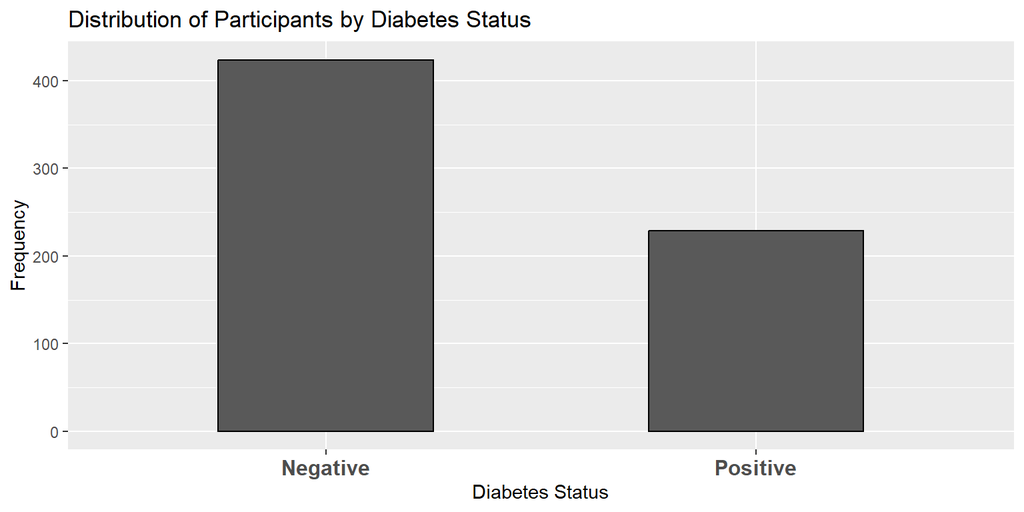

```r
barplot.diab <- ggplot(train,
                       aes(x=factor(diabetes))) +
  geom_bar(width = 0.5, color= "black") +
  labs(title = "Distribution of Participants by Diabetes Status",
       x = "Diabetes Status",
       y ="Frequency") +
  scale_x_discrete(labels = c("pos" = "Positive", "neg" = "Negative")) +
  theme(axis.text.x = element_text(face="bold", size=12))
barplot.diab
```

#### **4c. (2) How might class imbalance impact your diabetes classification analysis? Explain.**

#### When working on real-world problems, we often encounter datasets that are imbalanced in nature, especially on health-related issues. In these cases, in general, we are interested in detecting the presence of a disease (such as breast cancer or diabetes). However, because this feature of interest is often a minority in the population, we inevitably have an imbalanced dataset. In this context, most of the time we are more interested in the minority class, that is, determining whether a person actually has a disease. However, most machine learning algorithms for classification are designed for datasets with an equivalent number of examples for each class, often resulting in models with poor predictive performance, especially for the minority class examples. Therefore, the main challenge of working on classification problems with imbalanced datsets is exactly the lack of examples for the minority class and the difference in the importance of classification errors between classes, being often necessary to carry out additional steps, such as using re-sampling techniques (random undersampling and random oversampling) and alternative evaluation metrics (accuracy, recall and F-score).

#### **5a. (2) Based on the distribution of the target variable, which method should you use to correct for class imbalance: random undersampling or random oversampling? Why this method? Explain.**

#### **5b. (2) Based on your response in question 5a, use your chosen resampling strategy (undersampling or oversampling) to create a balanced training set, named `trainbal`. Set 468 as your random seed. After resampling, how many pos and neg values do you have in the `trainbal` dataset for the diabetes variable?**

```r
# Setting Seed
set.seed(468)
# Checking Imbalance and Distribution
table(train$diabetes)
```

```
##
## neg pos
## 424 229
```

```r
round(prop.table(table(train$diabetes)),2)
```

```
##
##  neg  pos
## 0.65 0.35
```

```r
# Testing a Model with Decision Tree
treeimb <- rpart(diabetes ~ ., data = train)
pred.treeimb <- predict(treeimb, newdata = test)
# Checking Accuracy Metrics
accuracy.meas(test$diabetes, pred.treeimb[,2])
```

```
##
## Call:
## accuracy.meas(response = test$diabetes, predicted = pred.treeimb[,
##     2])
##
## Examples are labelled as positive when predicted is greater than 0.5
##
## precision: 0.694
## recall: 0.641
## F: 0.333
```

```r
roc.curve(test$diabetes, pred.treeimb[,2], plotit = F)
```

```
## Area under the curve (AUC): 0.760
```

```r
# Creating Balanced Dataset
trainbal <- ovun.sample(diabetes ~ ., data = train, method = "over", N = 800)$data
# Checking Balanced Training Dataset
table(trainbal$diabetes)
```

```
##
## neg pos
## 424 376
```

#### As we see, the imbalanced dataset contains 35% of positive cases and 65% of negative cases., which is a somewthat imbalanced data set. So, to check how badly can this affect the prediction accuracy, a model was built on this data by means of decision tree algorithm for modeling purposes. These metrics from the decision tree model provided interesting information. As seen, with a threshold value of 0.5, a precision score of 0.694 says there may be false positives and a recall score of 0.641 is somewhat low and may indicate the presence of a higher number of false negatives. Likewise, a F score of 0.333 is also somewhat low and suggests weak-to-moderate accuracy of this model so far. For final decision, we shall check the accuracy of this model by means of the ROC curve which gives us a clearer picture about this model being worth or not. As observed, the ROC value of 0.760 means it not a good score about the model, which will get biased toward the majority class and fails to map minority class. Then, my performing the oversampling technique we obtain a new training data set with 424 negatives and 376 positives, satisfactory for analysis purposes.

#### **6a. (2) Using your balanced training data, use the tuneRF() function to tune the m (mtry) hyperparameter in a RF model. Use ntreeTry = 500, improve = 1e-5 and stepFactor = 2. Set doBest = TRUE so that the optimal model is created. First, set 468 as the random seed. What is the optimal m value?**

```r
# Setting Seed
set.seed(468)
# Tuning
rf.fit <- tuneRF(trainbal[,-9], trainbal[,9], 3, ntreeTry=500, stepFactor=2, improve=1e-5, doBest=TRUE)
```

```
## mtry = 3  OOB error = 12.75%
## Searching left ...
## mtry = 2     OOB error = 13%
## -0.01960784 1e-05
## Searching right ...
## mtry = 6     OOB error = 12.88%
## -0.009803922 1e-05
```

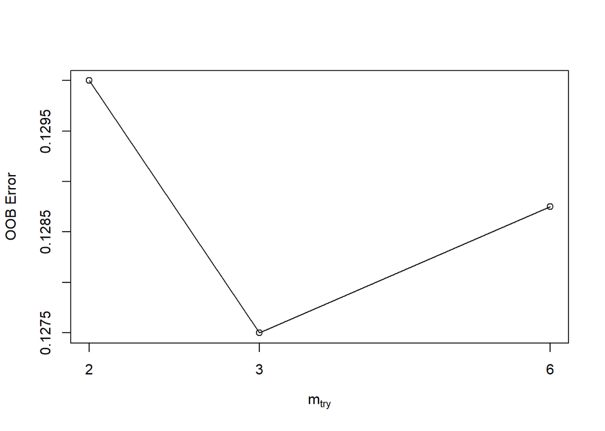

```r
print(rf.fit)
```

```
##
## Call:
##  randomForest(x = x, y = y, mtry = res[which.min(res[, 2]), 1])
##                Type of random forest: classification
##                      Number of trees: 500
## No. of variables tried at each split: 3
##
##         OOB estimate of  error rate: 12.75%
## Confusion matrix:
##     neg pos class.error
## neg 354  70  0.16509434
## pos  32 344  0.08510638
```

#### As observed, by suggesting a starting value of 3 for m, which usually is the square root of the number of variables in the data set, the tuning actually suggested 3 as the optimal value, by resulting in a OOBError of 12.75%. Therefore, we’d expect 3 to work just fine.

#### **6b. (2) What does the value of m (mtry) represent? What does the optimal value tell you about your RF model?**

#### The value of m, or mtry, means the number of variables selected at each split by the model. It is usually the square root of the number of variables in the data set. Thus, by being optimal, it means the random forest model works best with such number of splits.

#### **6c. (1) Based on the model, what are the top 3 most important variables?**

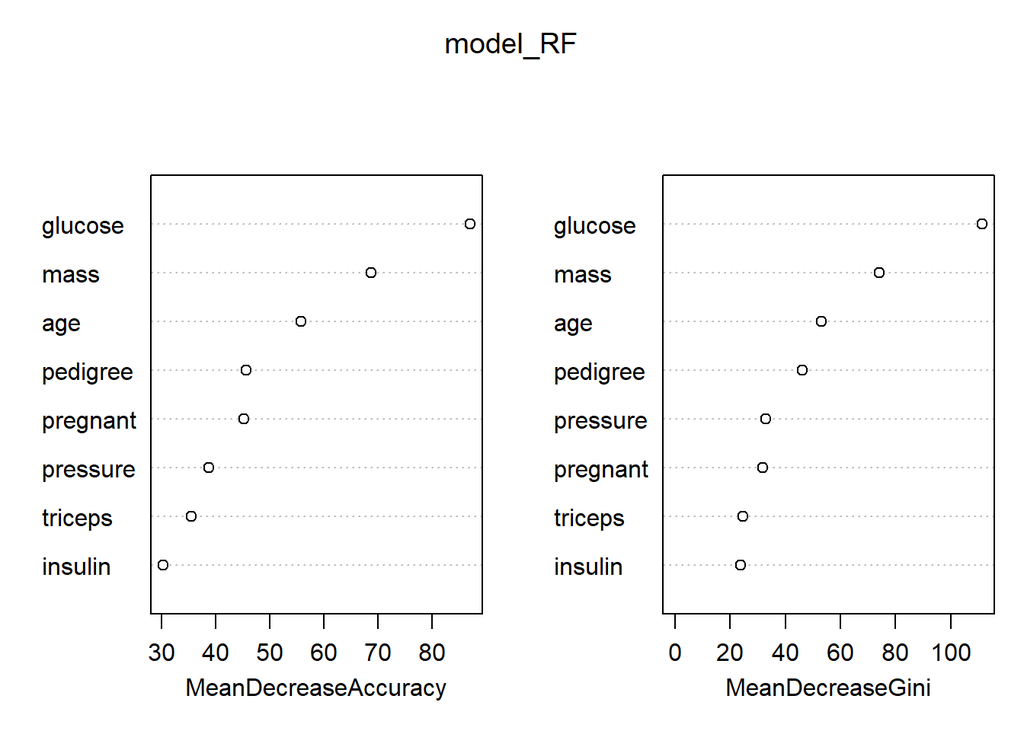

```r
# Model Fit
model_RF = randomForest(x = trainbal[,-9], y = trainbal[,9], ntree = 500, mtry = 3, importance = TRUE)
# Importance
varImpPlot(model_RF)
```

#### By observing the mean decrease accuracy plot we notice that the top 3 variables in importance are `glucose`, `mass`, and `age`.

#### **6d. (2) How can the doctor use variable importance information obtained from the random forest model? Explain.**

#### The accuracy from the plot above indicates by how much the model accuracy decreases (in %) if the so-called important variables are removed from the model. Therefore, the doctor can use this information on importance of the variables to know and prioritize their presence in the model, as well as understand how they affect the accuracy of predicting if a participant/patient will develop diabetes or not.

```r
# Predicting
RF.pred <- predict(model_RF, newdata = test)
# Confusion Matrix Statistics
confusionMatrix(RF.pred, test$diabetes, positive = "pos")
```

```
## Confusion Matrix and Statistics
##
##           Reference
## Prediction neg pos
##        neg  66  16
##        pos  10  23
##
##                Accuracy : 0.7739
##                  95% CI : (0.6865, 0.8467)
##     No Information Rate : 0.6609
##     P-Value [Acc > NIR] : 0.005687
##
##                   Kappa : 0.476
##
##  Mcnemar's Test P-Value : 0.326800
##
##             Sensitivity : 0.5897
##             Specificity : 0.8684
##          Pos Pred Value : 0.6970
##          Neg Pred Value : 0.8049
##              Prevalence : 0.3391
##          Detection Rate : 0.2000
##    Detection Prevalence : 0.2870
##       Balanced Accuracy : 0.7291
##
##        'Positive' Class : pos
##
```

```r
# Tabulation of Test Datatset Diabetes Status
table(test$diabetes)
```

```
##
## neg pos
##  76  39
```